# Performance

```python
# General Packages
import warnings
warnings.filterwarnings("ignore")
import numpy as np
import pandas as pd
import time

# General Mathematics package
import math as math

# Graphing Packages
import seaborn as sns
import matplotlib.pyplot as plt
%matplotlib inline
plt.style.use("ggplot")

# Statistics Packages
from scipy.stats import randint
from scipy.stats import skew

# Machine Learning Packages
from sklearn import linear_model
from sklearn.linear_model import LinearRegression
from sklearn.linear_model import LogisticRegression
from sklearn.model_selection import train_test_split
from sklearn.metrics import confusion_matrix
from sklearn.metrics import classification_report
from sklearn.metrics import accuracy_score
from sklearn.model_selection import GridSearchCV
from sklearn.neighbors import KNeighborsClassifier
from sklearn.tree import DecisionTreeClassifier
from sklearn.model_selection import RandomizedSearchCV
from sklearn.metrics import mean_squared_error
from sklearn.linear_model import Ridge
from sklearn.linear_model import Lasso
from sklearn.svm import SVC
from sklearn.pipeline import Pipeline
from sklearn.metrics import r2_score
from sklearn.preprocessing import StandardScaler
from sklearn.linear_model import Ridge
from sklearn.linear_model import Lasso
from sklearn.preprocessing import scale
from sklearn import preprocessing
from skimage.transform import resize
import xgboost as xgb

# Neural Network Packages
from keras.utils import np_utils
from keras.layers import Dense
from keras.models import Sequential
from keras.layers import Conv2D
from keras.layers import MaxPooling2D
from keras.layers import Flatten
from keras.preprocessing.image import ImageDataGenerator
from keras.callbacks import EarlyStopping
import tensorflow as tf

# H2o packages
import h2o
from h2o.automl import H2OAutoML
```

```python
student = pd.read_csv("StudentsPerformance.csv")
student.head()
```

|  | gender | race/ethnicity | parental level of education | lunch | test preparation course | math score | reading score | writing score |
| --- | --- | --- | --- | --- | --- | --- | --- | --- |
| 0 | female | group B | bachelor's degree | standard | none | 72 | 72 | 74 |
| 1 | female | group C | some college | standard | completed | 69 | 90 | 88 |
| 2 | female | group B | master's degree | standard | none | 90 | 95 | 93 |
| 3 | male | group A | associate's degree | free/reduced | none | 47 | 57 | 44 |
| 4 | male | group C | some college | standard | none | 76 | 78 | 75 |

We can create new columns in the dataframe to better our model and our visualization of the data

```python
student["overall score"] = np.nan
student["math score letter"] = np.nan
student["reading score letter"] = np.nan
student["writing score letter"] = np.nan
student["overall score letter"] = np.nan
```

```python
student["overall score"] = round((student["math score"] +
                                  student["reading score"] +
                                  student["writing score"])/3 , 2)
```

```python
student["math score letter"][student["math score"] <= 60] = "F"
student["math score letter"][np.logical_and
                             (student["math score"] > 60 ,
                              student["math score"] <= 69)] = "D"
student["math score letter"][np.logical_and
                             (student["math score"] >= 70 ,
                              student["math score"] <= 73)] = "C-"
student["math score letter"][np.logical_and
                             (student["math score"] >= 74 ,
                              student["math score"] <= 76)] = "C"
student["math score letter"][np.logical_and
                             (student["math score"] >= 77 ,
                              student["math score"] <= 79)] = "C+"
student["math score letter"][np.logical_and
                             (student["math score"] >= 80 ,
                              student["math score"] <= 83)] = "B-"
student["math score letter"][np.logical_and
                             (student["math score"] >= 84 ,
                              student["math score"] <= 86)] = "B"
student["math score letter"][np.logical_and
                             (student["math score"] >= 87 ,
                              student["math score"] <= 89)] = "B+"
student["math score letter"][np.logical_and
                             (student["math score"] >= 90 ,
                              student["math score"] <= 93)] = "A-"
student["math score letter"][np.logical_and
                             (student["math score"] >= 94 ,
                              student["math score"] <= 96)] = "A"
student["math score letter"][student["math score"] >= 97] = "A+"
```

```python
student["reading score letter"][student["reading score"] <= 60] = "F"
student["reading score letter"][np.logical_and
                             (student["reading score"] > 60 ,
                              student["reading score"] <= 69)] = "D"
student["reading score letter"][np.logical_and
                             (student["reading score"] >= 70 ,
                              student["reading score"] <= 73)] = "C-"
student["reading score letter"][np.logical_and
                             (student["reading score"] >= 74 ,
                              student["reading score"] <= 76)] = "C"
student["reading score letter"][np.logical_and
                             (student["reading score"] >= 77 ,
                              student["reading score"] <= 79)] = "C+"
student["reading score letter"][np.logical_and
                             (student["reading score"] >= 80 ,
                              student["reading score"] <= 83)] = "B-"
student["reading score letter"][np.logical_and
                             (student["reading score"] >= 84 ,
                              student["reading score"] <= 86)] = "B"
student["reading score letter"][np.logical_and
                             (student["reading score"] >= 87 ,
                              student["reading score"] <= 89)] = "B+"
student["reading score letter"][np.logical_and
                             (student["reading score"] >= 90 ,
                              student["reading score"] <= 93)] = "A-"
student["reading score letter"][np.logical_and
                             (student["reading score"] >= 94 ,
                              student["reading score"] <= 96)] = "A"
student["reading score letter"][student["reading score"] >= 97] = "A+"
```

```python
student["writing score letter"][student["writing score"] <= 60] = "F"
student["writing score letter"][np.logical_and
                             (student["writing score"] > 60 ,
                              student["writing score"] <= 69)] = "D"
student["writing score letter"][np.logical_and
                             (student["writing score"] >= 70 ,
                              student["writing score"] <= 73)] = "C-"
student["writing score letter"][np.logical_and
                             (student["writing score"] >= 74 ,
                              student["writing score"] <= 76)] = "C"
student["writing score letter"][np.logical_and
                             (student["writing score"] >= 77 ,
                              student["writing score"] <= 79)] = "C+"
student["writing score letter"][np.logical_and
                             (student["writing score"] >= 80 ,
                              student["writing score"] <= 83)] = "B-"
student["writing score letter"][np.logical_and
                             (student["writing score"] >= 84 ,
                              student["writing score"] <= 86)] = "B"
student["writing score letter"][np.logical_and
                             (student["writing score"] >= 87 ,
                              student["writing score"] <= 89)] = "B+"
student["writing score letter"][np.logical_and
                             (student["writing score"] >= 90 ,
                              student["writing score"] <= 93)] = "A-"
student["writing score letter"][np.logical_and
                             (student["writing score"] >= 94 ,
                              student["writing score"] <= 96)] = "A"
student["writing score letter"][student["writing score"] >= 97] = "A+"
```

```python
student["overall score letter"][student["overall score"] <= 60] = "F"
student["overall score letter"][np.logical_and
                             (student["overall score"] > 60 ,
                              student["overall score"] <= 69.99)] = "D"
student["overall score letter"][np.logical_and
                             (student["overall score"] >= 70 ,
                              student["overall score"] <= 73.99)] = "C-"
student["overall score letter"][np.logical_and
                             (student["overall score"] >= 74 ,
                              student["overall score"] <= 76.99)] = "C"
student["overall score letter"][np.logical_and
                             (student["overall score"] >= 77 ,
                              student["overall score"] <= 79.99)] = "C+"
student["overall score letter"][np.logical_and
                             (student["overall score"] >= 80 ,
                              student["overall score"] <= 83.99)] = "B-"
student["overall score letter"][np.logical_and
                             (student["overall score"] >= 84 ,
                              student["overall score"] <= 86.99)] = "B"
student["overall score letter"][np.logical_and
                             (student["overall score"] >= 87 ,
                              student["overall score"] <= 89.99)] = "B+"
student["overall score letter"][np.logical_and
                             (student["overall score"] >= 90 ,
                              student["overall score"] <= 93.99)] = "A-"
student["overall score letter"][np.logical_and
                             (student["overall score"] >= 94 ,
                              student["overall score"] <= 96.99)] = "A"
student["overall score letter"][student["overall score"] >= 97] = "A+"
```

```python
student.head()
```

|  | gender | race/ethnicity | parental level of education | lunch | test preparation course | math score | reading score | writing score | overall score | math score letter | reading score letter | writing score letter | overall score letter |
| --- | --- | --- | --- | --- | --- | --- | --- | --- | --- | --- | --- | --- | --- |
| 0 | female | group B | bachelor's degree | standard | none | 72 | 72 | 74 | 72.67 | C- | C- | C | C- |
| 1 | female | group C | some college | standard | completed | 69 | 90 | 88 | 82.33 | D | A- | B+ | B- |
| 2 | female | group B | master's degree | standard | none | 90 | 95 | 93 | 92.67 | A- | A | A- | A- |
| 3 | male | group A | associate's degree | free/reduced | none | 47 | 57 | 44 | 49.33 | F | F | F | F |
| 4 | male | group C | some college | standard | none | 76 | 78 | 75 | 76.33 | C | C+ | C | C |

Now that we have added some necessary columns, we can begin doing data visualization

```python
for n in range(0,5):
    student.iloc[:,n] = pd.Categorical(student.iloc[:,n])
# 0 to 5 changes gender to test prepartion course into category
for n in range(-1,-5):
    student.iloc[:,n] = pd.Categorical(student.iloc[:,n])
# -1 to -5 changes math score letter to overall score letter to category
student['overall score'] = pd.to_numeric(student["overall score"])
```

```python
student.info()
```

```
<class 'pandas.core.frame.DataFrame'>
RangeIndex: 1000 entries, 0 to 999
Data columns (total 13 columns):
gender                         1000 non-null category
race/ethnicity                 1000 non-null category
parental level of education    1000 non-null category
lunch                          1000 non-null category
test preparation course        1000 non-null category
math score                     1000 non-null int64
reading score                  1000 non-null int64
writing score                  1000 non-null int64
overall score                  1000 non-null float64
math score letter              1000 non-null object
reading score letter           1000 non-null object
writing score letter           1000 non-null object
overall score letter           1000 non-null object
dtypes: category(5), float64(1), int64(3), object(4)
memory usage: 68.1+ KB
```

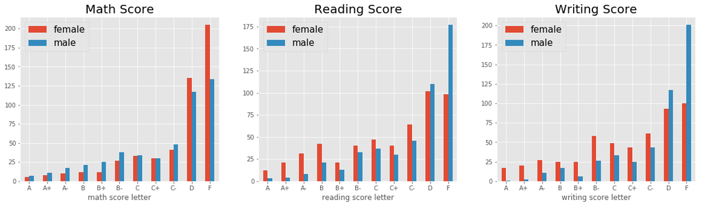

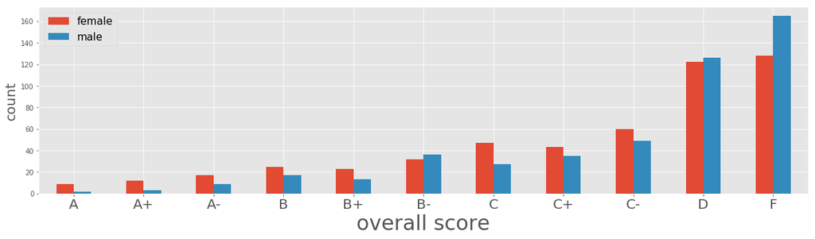

```python
plt.figure(figsize= (20,5))
ax = plt.subplot(131)
pd.crosstab(student["math score letter"] , student.gender).plot(kind = 'bar', ax = ax)
plt.xticks(rotation = 360)
plt.title("Math Score" , size = 20)
plt.legend(loc=2, prop={'size': 15})

ax1 = plt.subplot(132)
pd.crosstab(student["reading score letter"] , student.gender).plot(kind = 'bar', ax = ax1)
plt.xticks(rotation = 360)
plt.title("Reading Score" , size = 20)
plt.legend(loc=2, prop={'size': 15})

ax2 = plt.subplot(133)
pd.crosstab(student["writing score letter"] , student.gender).plot(kind = 'bar', ax = ax2)
plt.title("Writing Score" , size = 20)
plt.xticks(rotation = 360)
plt.legend(loc=2, prop={'size': 15})

pd.crosstab(student["overall score letter"] , student.gender).plot(kind = 'bar' , figsize = (20,5))
plt.xlabel("overall score", size = 30)
plt.xticks(rotation = 360 , size  = 20)
plt.ylabel("count" , size = 20)
plt.legend(loc=2, prop={'size': 15})
plt.show()
```

*From our graphs we can see that boys recieved a failing grade more than girls *Girls recieved a failing grade in math more than boys

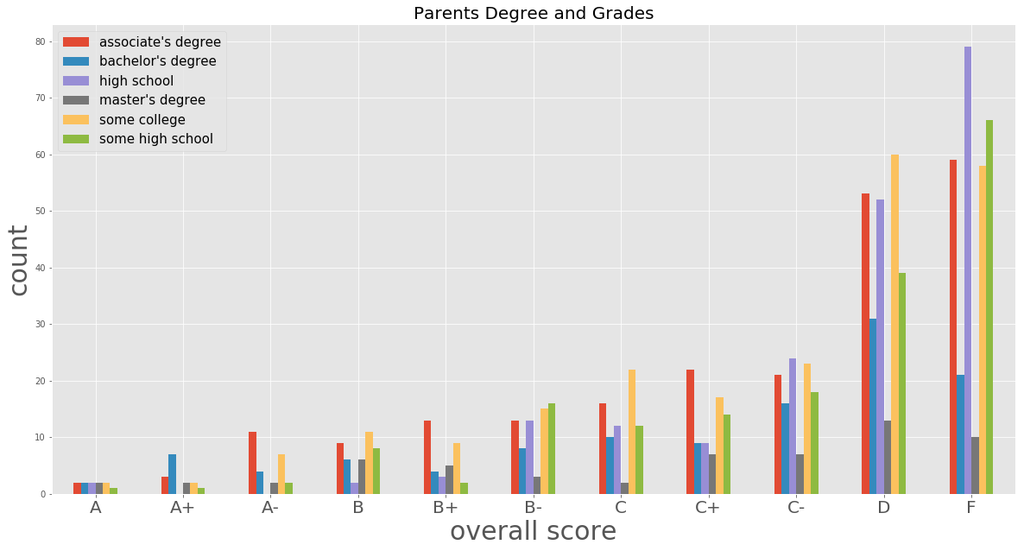

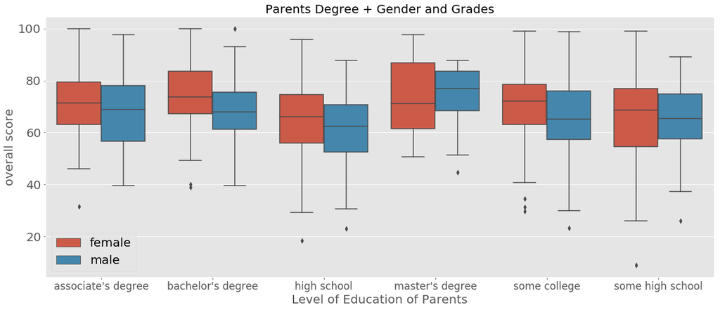

```python
pd.crosstab(student["overall score letter"],
            student["parental level of education"]).plot.bar(figsize = (20,10))

plt.xlabel("overall score", size = 30)
plt.xticks(rotation = 360 , size  = 20)
plt.ylabel("count" , size = 30)
plt.title("Parents Degree and Grades" , size = 20)
plt.legend(loc=2, prop={'size': 15})
plt.show()


plt.figure(figsize = (20,8))
sns.boxplot(x="parental level of education", y="overall score", hue="gender" ,
            data=student )
plt.xticks(rotation=360 , size = 17)
plt.yticks( size = 20)
plt.xlabel("Level of Education of Parents", size = 20)
plt.ylabel("overall score" , size = 20)
plt.title("Parents Degree + Gender and Grades" , size = 20)
plt.legend(loc=3, prop={'size': 20})
plt.show()
```

*The children with the most F's came from the families where the parents highest level education completed was high school. *Those children who's parents had the highest education (master's degree) got the best overall scores

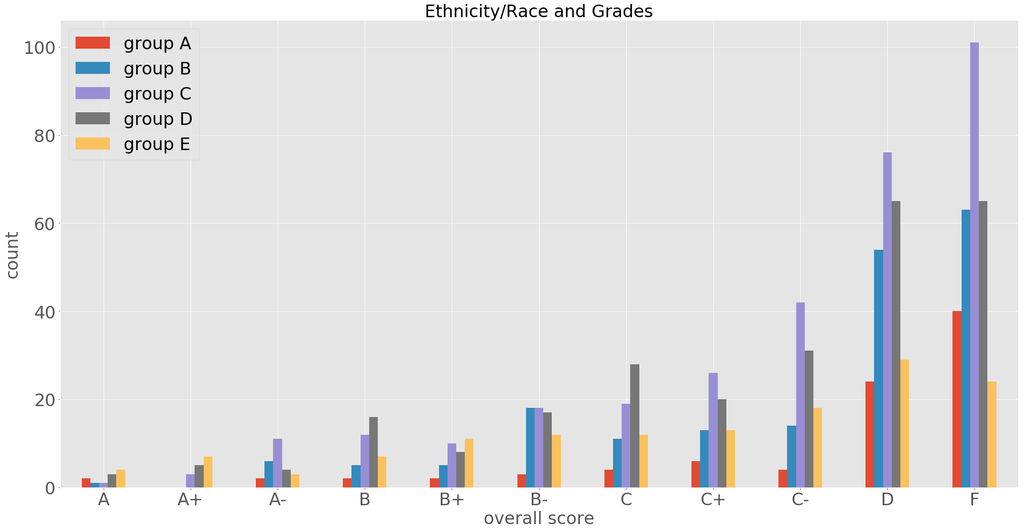

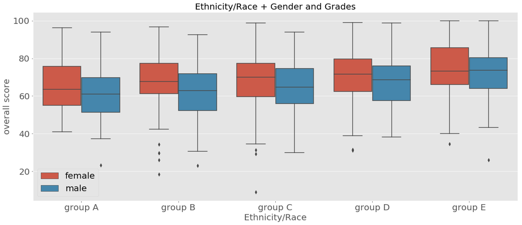

```python
pd.crosstab(student["overall score letter"],
            student["race/ethnicity"]).plot.bar(figsize = (30,15))

plt.xticks(rotation=360 , size = 30)
plt.yticks( size = 30)
plt.xlabel("overall score", size = 30)
plt.ylabel("count" , size = 30)
plt.title("Ethnicity/Race and Grades" , size = 30)
plt.legend(loc=2, prop={'size': 30})

plt.show()

plt.figure(figsize = (20,8))
sns.boxplot(x="race/ethnicity", y="overall score", hue="gender" ,
            data=student)
plt.xticks(rotation=360 , size = 20)
plt.yticks( size = 20)
plt.xlabel("Ethnicity/Race", size = 20)
plt.ylabel("overall score" , size = 20)
plt.title("Ethnicity/Race + Gender and Grades" , size = 20)
plt.legend(loc=3, prop={'size': 20})
plt.show()
```

*The most F's came from Group C of the ethnicity/race *The best overall grades came from group E of the data.

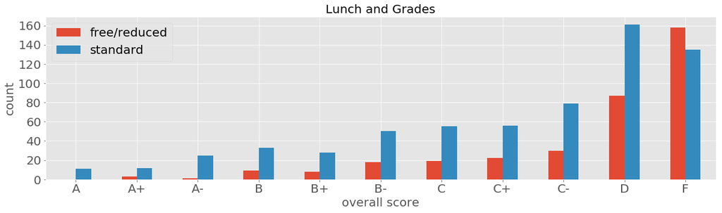

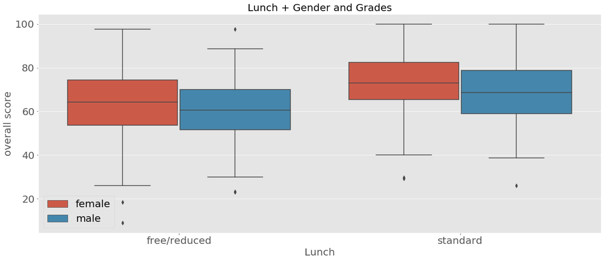

```python
pd.crosstab(student["overall score letter"],
            student["lunch"]).plot.bar(figsize = (20,5))
plt.xticks(rotation=360 , size = 20)
plt.yticks( size = 20)
plt.xlabel("overall score", size = 20)
plt.ylabel("count" , size = 20)
plt.title("Lunch and Grades" , size = 20)
plt.legend(loc=2, prop={'size': 20})
plt.show()

plt.figure(figsize = (20,8))
sns.boxplot(x="lunch", y="overall score", hue="gender" ,
            data=student)
plt.xticks(rotation=360 , size = 20)
plt.yticks( size = 20)
plt.xlabel("Lunch", size = 20)
plt.ylabel("overall score" , size = 20)
plt.title("Lunch + Gender and Grades" , size = 20)
plt.legend(loc=3, prop={'size': 20})
plt.show()
```

*Those who receieved free/reduced lunch had the most F's *Those who received standard lunch did better on their exams than the ones with free/reduced lunch

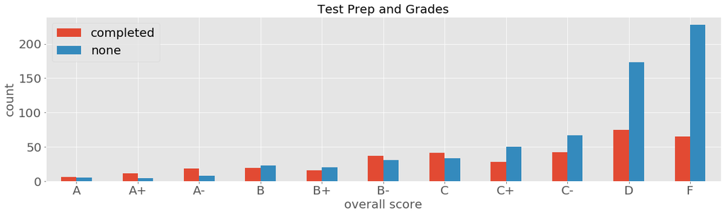

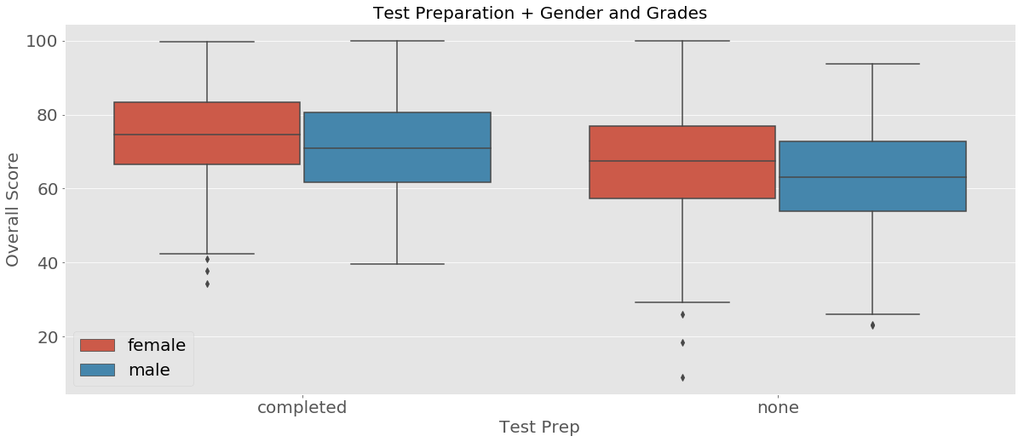

```python
pd.crosstab(student["overall score letter"],
            student["test preparation course"]).plot.bar(figsize = (20,5))
plt.xticks(rotation = 360)
plt.xticks(rotation=360 , size = 20)
plt.yticks( size = 20)
plt.xlabel("overall score", size = 20)
plt.ylabel("count" , size = 20)
plt.title("Test Prep and Grades" , size = 20)
plt.legend(loc=2, prop={'size': 20})
plt.show()

plt.figure(figsize = (20,8))
sns.boxplot(x="test preparation course", y="overall score", hue="gender" ,
            data=student)
plt.xticks(rotation=360 , size = 20)
plt.yticks( size = 20)
plt.xlabel("Test Prep", size = 20)
plt.ylabel("Overall Score" , size = 20)
plt.title("Test Preparation + Gender and Grades" , size = 20)
plt.legend(loc=3, prop={'size': 20})
plt.show()
```

*Those who took the test prep did better than the ones who did not

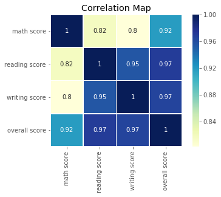

```python
sns.heatmap(student.corr() , square = True , annot = True ,
            linewidths=.8 , cmap="YlGnBu")
plt.title("Correlation Map")
plt.show()
```

Based on the heat map there is a strong correlation between reading and writing score as opposed to math scores.

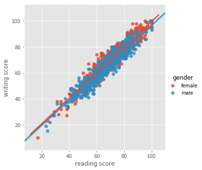

```python
sns.lmplot(x="reading score", y="writing score", hue="gender",
           data=student)
plt.show()
```

Now we can perform our machine learning for the following questions: 1) If I did not make an overall score , can I correctly predict their overall score solely based on reading, writing and math scores? (I can predict the letter grade so we can make this into a classification problem)

```python
student_1 = student
```

```python
le = preprocessing.LabelEncoder()
for n in range(0,5):
    student_1.iloc[:,n] = le.fit_transform(student_1.iloc[:,n])
```

```python
for n in range(0,5):
    student_1.iloc[:,n] = pd.Categorical(student_1.iloc[:,n])
student_1['overall score'] = pd.to_numeric(student_1["overall score"])
```

```python
student_1["math score letter"] = pd.Categorical(student_1["math score letter"])
student_1["reading score letter"] = pd.Categorical(student_1["reading score letter"])
student_1["writing score letter"] = pd.Categorical(student_1["writing score letter"])
student_1["overall score letter"] = pd.Categorical(student_1["overall score letter"])
```

```python
student_2 = student_1
```

```python
student_1 = student_1.replace(["F" , "D" , "C-" , "C" , "C+", "B-" , "B" , "B+", "A-" , "A" , "A+"] , [0,1,2,3,4,5,6,7,8,9,10])

#    F = 0
#    D = 1
#    C- = 2
#    C = 3
#    C+ = 4
#    B- = 5
#    B = 6
#    B+ = 7
#    A- = 8
#    A = 9
#    A+ = 10
```

```python
student_1.head()
```

|  | gender | race/ethnicity | parental level of education | lunch | test preparation course | math score | reading score | writing score | overall score | math score letter | reading score letter | writing score letter | overall score letter |
| --- | --- | --- | --- | --- | --- | --- | --- | --- | --- | --- | --- | --- | --- |
| 0 | 0 | 1 | 1 | 1 | 1 | 72 | 72 | 74 | 72.67 | 2 | 2 | 3 | 2 |
| 1 | 0 | 2 | 4 | 1 | 0 | 69 | 90 | 88 | 82.33 | 1 | 8 | 7 | 5 |
| 2 | 0 | 1 | 3 | 1 | 1 | 90 | 95 | 93 | 92.67 | 8 | 9 | 8 | 8 |
| 3 | 1 | 0 | 0 | 0 | 1 | 47 | 57 | 44 | 49.33 | 0 | 0 | 0 | 0 |
| 4 | 1 | 2 | 4 | 1 | 1 | 76 | 78 | 75 | 76.33 | 3 | 4 | 3 | 3 |

```python
X_score = student_1.drop(["overall score letter" , "overall score"] , axis = 1)
y_score = student_1["overall score letter"]

X_train, X_val, y_train, y_val = train_test_split(X_score, y_score, test_size = 0.3, random_state=42)
```

Logistic Regression: Predicting Overall Score

```python
logreg = LogisticRegression()
logreg.fit(X_train , y_train)
y_pred = logreg.predict(X_val)

#print(confusion_matrix(y_val,y_pred))
print(classification_report(y_val , y_pred))
print("accuracy",accuracy_score(y_val , y_pred)*100,"%")
```

```
             precision    recall  f1-score   support

          0       0.95      0.97      0.96        96
          1       0.59      0.93      0.72        73
          2       0.00      0.00      0.00        28
          3       0.50      0.12      0.19        26
          4       0.33      0.25      0.29        24
          5       0.32      0.44      0.37        18
          6       0.00      0.00      0.00        13
          7       0.00      0.00      0.00        12
          8       0.22      0.50      0.31         4
          9       0.00      0.00      0.00         3
         10       0.50      0.33      0.40         3

avg / total       0.54      0.60      0.55       300

accuracy 60.333333333333336 %
```

KNN: Predicting Overall Score

```python
param_grid = {'n_neighbors' : np.arange(1,50)}

knn_cv = KNeighborsClassifier()

knn_cv = GridSearchCV(knn_cv, param_grid, cv = 5)

knn_cv.fit(X_train , y_train)

print(knn_cv.best_params_)

print(knn_cv.best_score_)

y_pred_knn = knn_cv.predict(X_val)

print("accuracy:" , accuracy_score(y_val , y_pred_knn)*100 , "%")
```

```
{'n_neighbors': 7}
0.91
accuracy: 93.0 %
```

Decision Tree: Predicting Overall Score

```python
tree = DecisionTreeClassifier()

tree.fit(X_train , y_train)
y_pred_DT = tree.predict(X_val)
#print(confusion_matrix(y_val,y_pred))
print(classification_report(y_val , y_pred_DT))
print("accuracy:",round(accuracy_score(y_val , y_pred_DT)*100,2) , "%")
```

```
             precision    recall  f1-score   support

          0       0.93      0.97      0.95        96
          1       0.91      0.84      0.87        73
          2       0.77      0.82      0.79        28
          3       0.73      0.62      0.67        26
          4       0.57      0.71      0.63        24
          5       0.71      0.56      0.63        18
          6       0.44      0.62      0.52        13
          7       0.50      0.33      0.40        12
          8       0.60      0.75      0.67         4
          9       1.00      1.00      1.00         3
         10       1.00      1.00      1.00         3

avg / total       0.81      0.80      0.80       300

accuracy: 80.33 %
```

Decision Tree + GridSearchCV: Predicting Overall Score

```python
param_dist = {'max_depth' : [3,None],
             'max_features' : np.arange(1,9),
             'min_samples_leaf':np.arange(1,9),
             "criterion" :["gini" , "entropy"]}
tree = DecisionTreeClassifier()
tree_cv = GridSearchCV(tree , param_dist , cv = 10 , verbose = 1)
tree_cv.fit(X_train , y_train)
y_pred_RF = tree_cv.predict(X_val)
#print(confusion_matrix(y_val,y_pred))
print(classification_report(y_val , y_pred_RF))
print("accuracy:",round(accuracy_score(y_val , y_pred_RF)*100,2),"%")
```

```
Fitting 10 folds for each of 256 candidates, totalling 2560 fits
```

```
[Parallel(n_jobs=1)]: Done 2560 out of 2560 | elapsed:   12.2s finished
```

```
             precision    recall  f1-score   support

          0       0.94      0.98      0.96        96
          1       0.94      0.81      0.87        73
          2       0.64      0.82      0.72        28
          3       0.65      0.58      0.61        26
          4       0.61      0.79      0.69        24
          5       0.92      0.67      0.77        18
          6       0.71      0.77      0.74        13
          7       0.56      0.42      0.48        12
          8       0.29      0.50      0.36         4
          9       1.00      0.67      0.80         3
         10       1.00      0.67      0.80         3

avg / total       0.83      0.81      0.81       300

accuracy: 81.0 %
```

Decision Tree + RandomizedSearchCV: Predicting overall score

```python
param_dist = {'max_depth' : [3,None],
             'max_features' : np.arange(1,9),
             'min_samples_leaf':np.arange(1,9),
             "criterion" :["gini" , "entropy"]}
tree = DecisionTreeClassifier()
tree_cv = RandomizedSearchCV(tree , param_dist , cv = 10 , verbose = 1)
tree_cv.fit(X_train , y_train)
y_pred_RF = tree_cv.predict(X_val)
#print(confusion_matrix(y_val,y_pred))
print(classification_report(y_val , y_pred_RF))
print("accuracy:",round(accuracy_score(y_val , y_pred_RF)*100,2),"%")
```

```
Fitting 10 folds for each of 10 candidates, totalling 100 fits
```

```
[Parallel(n_jobs=1)]: Done 100 out of 100 | elapsed:    0.4s finished
```

```
             precision    recall  f1-score   support

          0       0.93      0.96      0.94        96
          1       0.87      0.82      0.85        73
          2       0.62      0.75      0.68        28
          3       0.71      0.46      0.56        26
          4       0.60      0.75      0.67        24
          5       0.70      0.78      0.74        18
          6       0.70      0.54      0.61        13
          7       0.78      0.58      0.67        12
          8       0.57      1.00      0.73         4
          9       0.67      0.67      0.67         3
         10       1.00      0.67      0.80         3

avg / total       0.80      0.80      0.79       300

accuracy: 79.67 %
```

SVC: Predicting Overall Score

```python
warnings.filterwarnings("ignore")

clf = SVC()

clf.fit(X_train , y_train)

y_pred_SVC = clf.predict(X_val)

print(classification_report(y_val , y_pred_SVC))
print('accuracy:' , accuracy_score(y_val , y_pred_SVC)*100,"%")
```

```
             precision    recall  f1-score   support

          0       0.70      1.00      0.82        96
          1       0.97      0.86      0.91        73
          2       1.00      0.89      0.94        28
          3       0.91      0.81      0.86        26
          4       0.91      0.83      0.87        24
          5       0.83      0.56      0.67        18
          6       1.00      0.62      0.76        13
          7       0.50      0.08      0.14        12
          8       1.00      0.75      0.86         4
          9       0.00      0.00      0.00         3
         10       1.00      0.67      0.80         3

avg / total       0.84      0.83      0.81       300

accuracy: 83.0 %
```

XGBoost: Predicting Overall Score

```python
student_int = student_1[0:-1].astype("int64")

X_score_int = student_int.drop(["overall score letter" ,"overall score"] , axis = 1)
y_score_int = student_int["overall score letter"]

X_train_int, X_val_int, y_train_int, y_val_int = train_test_split(X_score_int, y_score_int, test_size = 0.3, random_state=42)
```

```python
warnings.filterwarnings("ignore")

xg = xgb.XGBClassifier(objective='reg:logistic', n_estimators = 10, seed=1234)
xg.fit(X_train_int, y_train_int)

y_pred_XGB = xg.predict(X_val_int)

print("accuracy:",round(accuracy_score(y_val_int, y_pred_XGB)*100,2) , "%")
```

```
accuracy: 76.67 %
```

```python
student_2.replace(["C-" , "C" , "C+" ,] , ("C") , inplace = True)
student_2.replace(["B-" , "B" , "B+" ,] , ("B") , inplace = True)
student_2.replace(["A-" , "A" , "A+" ,] , ("A") , inplace = True)
```

```python
student_2.replace(["F" , "D" , "C" , "B" , "A"] , (0,1,2,3,4) , inplace = True)

#    F = 0
#    D = 1
#    C = 2
#    B = 3
#    A = 4
```

```python
X_score = student_2.drop(["overall score letter" , "overall score"] , axis = 1)
y_score = student_2["overall score letter"]

X_train, X_test, y_train, y_test = train_test_split(X_score, y_score, test_size = 0.3, random_state=42)
```

Logistic Regression: Predicting overall score letter with reduced categories

```python
logreg = LogisticRegression()
logreg.fit(X_train , y_train)
y_pred = logreg.predict(X_test)

#print(confusion_matrix(y_val,y_pred))
print(classification_report(y_test , y_pred))
print("accuracy",accuracy_score(y_test , y_pred)*100,"%")
```

```
             precision    recall  f1-score   support

          0       0.94      0.98      0.96        96
          1       0.77      0.68      0.72        73
          2       0.64      0.78      0.70        78
          3       0.71      0.51      0.59        43
          4       0.62      0.50      0.56        10

avg / total       0.78      0.77      0.77       300

accuracy 77.33333333333333 %
```

Decision Tree: Predicting overall score letter with reduced categories

```python
tree = DecisionTreeClassifier()

tree.fit(X_train , y_train)
y_pred_DT = tree.predict(X_test)
#print(confusion_matrix(y_val,y_pred))
print(classification_report(y_test , y_pred_DT))
print("accuracy:",round(accuracy_score(y_test , y_pred_DT)*100,2) , "%")
```

```
             precision    recall  f1-score   support

          0       0.96      0.97      0.96        96
          1       0.89      0.89      0.89        73
          2       0.88      0.87      0.88        78
          3       0.83      0.79      0.81        43
          4       0.75      0.90      0.82        10

avg / total       0.90      0.90      0.90       300

accuracy: 89.67 %
```

Decision Tree + GridsearchCV: Predicting overall score letter with reduced categories

```python
param_dist = {'max_depth' : [3,None],
             'max_features' : np.arange(1,9),
             'min_samples_leaf':np.arange(1,9),
             "criterion" :["gini" , "entropy"]}
tree = DecisionTreeClassifier()
tree_cv = GridSearchCV(tree , param_dist , cv = 10 , verbose = 1)
tree_cv.fit(X_train , y_train)
y_pred_RF = tree_cv.predict(X_test)
#print(confusion_matrix(y_val,y_pred))
print(classification_report(y_test , y_pred_RF))
print("accuracy:",round(accuracy_score(y_test , y_pred_RF)*100,2),"%")
```

```
Fitting 10 folds for each of 256 candidates, totalling 2560 fits
```

```
[Parallel(n_jobs=1)]: Done 2560 out of 2560 | elapsed:    4.9s finished
```

```
             precision    recall  f1-score   support

          0       0.94      0.95      0.94        96
          1       0.88      0.86      0.87        73
          2       0.89      0.90      0.89        78
          3       0.84      0.72      0.77        43
          4       0.60      0.90      0.72        10

avg / total       0.88      0.88      0.88       300

accuracy: 88.0 %
```

Decision Tree + RandomizedSearchCV: Predicting overall score letter with reduced categories

```python
param_dist = {'max_depth' : [3,None],
             'max_features' : np.arange(1,9),
             'min_samples_leaf':np.arange(1,9),
             "criterion" :["gini" , "entropy"]}
tree = DecisionTreeClassifier()
tree_cv = RandomizedSearchCV(tree , param_dist , cv = 10 , verbose = 1)
tree_cv.fit(X_train , y_train)
y_pred_RF = tree_cv.predict(X_test)
#print(confusion_matrix(y_val,y_pred))
print(classification_report(y_test , y_pred_RF))
print("accuracy:",round(accuracy_score(y_test , y_pred_RF)*100,2),"%")
```

```
Fitting 10 folds for each of 10 candidates, totalling 100 fits
```

```
[Parallel(n_jobs=1)]: Done 100 out of 100 | elapsed:    0.1s finished
```

```
             precision    recall  f1-score   support

          0       0.93      0.98      0.95        96
          1       0.91      0.81      0.86        73
          2       0.83      0.94      0.88        78
          3       0.97      0.77      0.86        43
          4       0.83      1.00      0.91        10

avg / total       0.90      0.90      0.90       300

accuracy: 89.67 %
```

SVC: Predicting overall score letter with reduced categories

```python
warnings.filterwarnings("ignore")

clf = SVC()

clf.fit(X_train , y_train)

y_pred_SVC = clf.predict(X_test)

print(classification_report(y_test , y_pred_SVC))
print('accuracy:' , round(accuracy_score(y_test , y_pred_SVC)*100,2),"%")
```

```
             precision    recall  f1-score   support

          0       0.79      1.00      0.88        96
          1       1.00      0.88      0.93        73
          2       0.97      0.95      0.96        78
          3       0.97      0.74      0.84        43
          4       0.83      0.50      0.62        10

avg / total       0.92      0.90      0.90       300

accuracy: 90.33 %
```

XGBoost: Predicting overall score letter with reduced categories

```python
student_int = student_2[0:-1].astype("int64")

X_score_int = student_int.drop(["overall score letter" ,"overall score"] , axis = 1)
y_score_int = student_int["overall score letter"]

X_train_int, X_test_int, y_train_int, y_test_int = train_test_split(X_score_int, y_score_int, test_size = 0.3, random_state=42)
```

```python
warnings.filterwarnings("ignore")

xg = xgb.XGBClassifier(objective='reg:logistic', n_estimators = 10, seed=1234)
xg.fit(X_train_int, y_train_int)

y_pred_XGB = xg.predict(X_test_int)

print("accuracy:",round(accuracy_score(y_test_int, y_pred_XGB)*100,2) , "%")
```

```
accuracy: 91.0 %
```

Reducing the number of categories significantly increased our accuracy, our best accuracy being 91% via XGBoost 4) What will be our R^2 value if we performed regression instead of classification?

```python
X_score = student_1.drop(["overall score letter" , "overall score"] , axis = 1)
y_score = student_1["overall score"]

X_train, X_test, y_train, y_test = train_test_split(X_score, y_score, test_size = 0.3, random_state=42)
```

Linear Regression: Predicting overall numerical score

```python
reg = linear_model.LinearRegression()
reg.fit(X_train , y_train)
y_pred_reg = reg.predict(X_test)

RMSE = np.sqrt(mean_squared_error(y_test,y_pred_reg))
print("RMSE: " , RMSE)
MSE = mean_squared_error(y_test,y_pred_reg )
print("MSE: " ,MSE)
print("R^2: " , r2_score(y_test, y_pred_reg))
```

```
RMSE:  0.002617684403513125
MSE:  6.852271636395866e-06
R^2:  0.9999999696042335
```

Ridge Regression: Predicting overall numerical score

```python
ridge = Ridge(alpha = 0.4 , normalize = True)

ridge.fit(X_train, y_train)
ridge_pred = ridge.predict(X_test)
print("RMSE: " , np.sqrt(mean_squared_error(y_test,ridge_pred)))
print("MSE: " , mean_squared_error(y_test,ridge_pred))
print("R^2: " , r2_score(y_test, ridge_pred))
```

```
RMSE:  2.7192759215235607
MSE:  7.39446153737781
R^2:  0.9671991512201854
```

Lasso Regression: Predicting overall numerical score

```python
lasso = Lasso(alpha = 0.4, normalize = True , max_iter = 1000000)

lasso.fit(X_train,y_train)

lasso_pred = ridge.predict(X_test)
print("RMSE: " , np.sqrt(mean_squared_error(y_test,lasso_pred)))
print("MSE: " , mean_squared_error(y_test,lasso_pred))
print("R^2: " , r2_score(y_test, lasso_pred))
```

```
RMSE:  2.7192759215235607
MSE:  7.39446153737781
R^2:  0.9671991512201854
```

Regression gives us a high R^2 value which is also a noteable method for our machine learning practices.4) As I saw in the graph earlier, girls did better on their score than boys, can we obtain a good accuracy on predicting whether the student is a girl or boy?

```python
X_score = student_1.drop(["gender"] , axis = 1)
y_score = student_1["gender"]

X_train, X_val, y_train, y_val = train_test_split(X_score, y_score, test_size = 0.3, random_state=42)
```

Logistic Regression: Predicting Gender

```python
logreg = LogisticRegression()
logreg.fit(X_train , y_train)
y_pred = logreg.predict(X_val)

#print(confusion_matrix(y_val,y_pred))
print(classification_report(y_val , y_pred))
print("accuracy",round(accuracy_score(y_val , y_pred)*100,2),"%")
```

```
             precision    recall  f1-score   support

          0       0.88      0.94      0.91       143
          1       0.94      0.88      0.91       157

avg / total       0.91      0.91      0.91       300

accuracy 90.67 %
```

KNN: Predicting Gender

```python
param_grid = {'n_neighbors' : np.arange(1,50)}

knn_cv = KNeighborsClassifier()

knn_cv = GridSearchCV(knn_cv, param_grid, cv = 5)

knn_cv.fit(X_train , y_train)

print(knn_cv.best_params_)

print(knn_cv.best_score_)

y_pred_knn = knn_cv.predict(X_val)

print("accuracy:" , round(accuracy_score(y_val , y_pred_knn)*100,2) , "%")
```

```
{'n_neighbors': 3}
0.8542857142857143
accuracy: 82.33 %
```

```python
tree = DecisionTreeClassifier()

tree.fit(X_train , y_train)
y_pred_DT = tree.predict(X_val)
#print(confusion_matrix(y_val,y_pred))
print(classification_report(y_val , y_pred_DT))
print("accuracy:",accuracy_score(y_val , y_pred_DT)*100 , "%")
```

```
             precision    recall  f1-score   support

          0       0.78      0.83      0.81       143
          1       0.84      0.79      0.81       157

avg / total       0.81      0.81      0.81       300

accuracy: 81.0 %
```

Decision Tree + GridSearch: Predicting Gender

```python
param_dist = {'max_depth' : [3,None],
             'max_features' : np.arange(1,9),
             'min_samples_leaf':np.arange(1,9),
             "criterion" :["gini" , "entropy"]}
tree = DecisionTreeClassifier()
tree_cv = GridSearchCV(tree , param_dist , cv = 5 , verbose = 1)
tree_cv.fit(X_train , y_train)
y_pred_RF = tree_cv.predict(X_val)
#print(confusion_matrix(y_val,y_pred))
print(classification_report(y_val , y_pred_RF))
print("accuracy:",round(accuracy_score(y_val , y_pred_RF)*100,2),"%")
```

```
Fitting 5 folds for each of 256 candidates, totalling 1280 fits
```

```
[Parallel(n_jobs=1)]: Done 1280 out of 1280 | elapsed:    6.7s finished
```

```
             precision    recall  f1-score   support

          0       0.76      0.90      0.83       143
          1       0.89      0.75      0.81       157

avg / total       0.83      0.82      0.82       300

accuracy: 82.0 %
```

Decision Tree + RandomSearch: Predicting Gender

```python
param_dist = {'max_depth' : [3,None],
             'max_features' : np.arange(1,9),
             'min_samples_leaf':np.arange(1,9),
             "criterion" :["gini" , "entropy"]}
tree = DecisionTreeClassifier()
tree_cv = RandomizedSearchCV(tree , param_dist , cv = 5 , verbose = 1)
tree_cv.fit(X_train , y_train)
y_pred_RF = tree_cv.predict(X_val)
#print(confusion_matrix(y_val,y_pred))
print(classification_report(y_val , y_pred_RF))
print("accuracy:",round(accuracy_score(y_val , y_pred_RF)*100,2),"%")
```

```
Fitting 5 folds for each of 10 candidates, totalling 50 fits
```

```
[Parallel(n_jobs=1)]: Done  50 out of  50 | elapsed:    0.2s finished
```

```
             precision    recall  f1-score   support

          0       0.77      0.79      0.78       143
          1       0.80      0.78      0.79       157

avg / total       0.79      0.79      0.79       300

accuracy: 78.67 %
```

SVC: Predicting Gender

```python
warnings.filterwarnings("ignore")

clf = SVC()

clf.fit(X_train , y_train)

y_pred_SVC = clf.predict(X_val)

print(classification_report(y_val , y_pred_SVC))
print('accuracy:' , round(accuracy_score(y_val , y_pred_SVC)*100,2),"%")
```

```
             precision    recall  f1-score   support

          0       0.77      0.90      0.83       143
          1       0.89      0.76      0.82       157

avg / total       0.83      0.82      0.82       300

accuracy: 82.33 %
```

XGBoost: Predicting Gender

```python
student_int = student_1[0:-1].astype("int64")

X_score_int = student_int.drop(["gender"] , axis = 1)
y_score_int = student_int["gender"]

X_train_int, X_val_int, y_train_int, y_val_int = train_test_split(X_score_int, y_score_int, test_size = 0.3, random_state=42)
```

```python
warnings.filterwarnings("ignore")

xg = xgb.XGBClassifier(objective='reg:logistic', n_estimators = 10, seed=1234)
xg.fit(X_train_int, y_train_int)

y_pred_XGB = xg.predict(X_val_int)

print("accuracy:",accuracy_score(y_val_int, y_pred_XGB)*100 , "%")
```

```
accuracy: 83.0 %
```

Overall we were able to get 90% accuracy in predicting the gender via Logistic Regression.4) Can we use unsupervised learning (such as KMeans), to predicting gender based on reading and math scores?Unsupervised Learning: KMeans Clustering

```python
student = pd.read_csv("StudentsPerformance.csv")
```

```python
from sklearn.cluster import KMeans

gender = student_1['gender'].values
X_gen = student_1.drop('gender' , axis = 1).values
```

```python
model = KMeans(n_clusters = 2)
model.fit(X_gen)
labels = model.predict(X_gen)
```

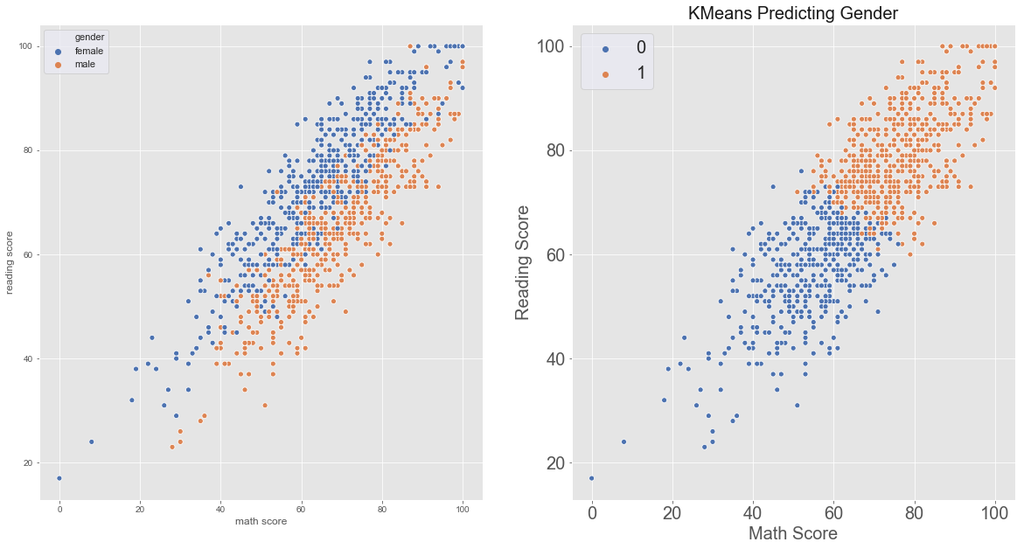

```
                                                       accuracy: 44.6 %
```

```python
xs = X_gen[:,4]
ys = X_gen[:,5]

f, (ax1, ax2) = plt.subplots(figsize=(20, 10) , ncols = 2)

sns.set()

sns.scatterplot(x="math score", y="reading score", hue="gender" , data=student , ax = ax1)
plt.xticks(rotation=360 , size = 20)
plt.yticks( size = 20)
plt.xlabel("Math Score", size = 20)
plt.ylabel("Reading Score" , size = 20)
plt.title("Actual Gender Data" , size = 20)
#plt.legend(loc=2, prop={'size': 20})

sns.scatterplot(x = xs,y = ys , hue = labels , ax=ax2)
plt.xlabel("Math Score" , size = 20)
plt.ylabel("Reading Score" , size = 20)
plt.title("KMeans Predicting Gender" , size = 20)
plt.legend(loc=2, prop={'size': 20})
plt.show()

acc = round(accuracy_score(labels , student_1.gender)*100,2)
print(('accuracy: '+ str(acc)+" %").center(125))
```